# Making a phylogenetic tree using #Invertefest observations

Author

Maxime Dahirel

Published

2023-09-01

> #InverteFest is a periodic online event where we invite you to celebrate the overlooked invertebrate fauna around you and share the joys of discovery online.  
> The hashtag was conceived when [Franz Anthony](https://franzanth.com/) and [Maureen Berg](https://maureenbug.github.io/) went looking for bugs and slugs in Bali. [Kelly Brenner](https://www.metrofieldguide.com/), stuck in Seattle, wondered if we could invite our online friends to look for bugs and slugs together in spirit, even though we’re physically far apart. Besides, what may be an everyday creature to you is often exciting to someone who lives half the world away!

(from the [#Invertefest August 2023 page on iNaturalist](https://www.inaturalist.org/projects/invertefest-august-2023))

During this summer’s (2023) #Invertefest, I randomly decided it would be neat to try and make a phylogenetic tree from all the iNat observations.

**Code: load packages**

```r
library(tidyverse) # CRAN v2.0.0
library(httr)      # CRAN v1.4.7
library(ape)       # CRAN v5.7-1
library(rotl)      # CRAN v3.1.0
library(ggtree)    # Bioconductor v3.8.2
library(ggtext)    # CRAN v0.1.2
library(rphylopic) # CRAN v1.1.1
library(showtext)  # CRAN v0.9-6
library(here)      # CRAN v1.0.1
```

# Loading iNat observations

There are in two main options to get the list of observed taxa. We can rely on data predownloaded manually through the [website](https://www.inaturalist.org/observations/export?projects=invertefest-august-2023), or we can directly query the API via `httr::GET()`.

**Code: load data from pre-downloaded csv**

```r
#invertefest_summer23 <- read_csv(here("raw_data","observations-354487.csv"))
```

**Code: get data by request to the iNat API, then parse the result**

```r
# first let's make a general request to see how many obs there is
request <- GET("https://api.inaturalist.org/v1/observations?project_id=invertefest-august-2023")
request_parsed <- content(request)
N_obs <- request_parsed$total_results
# this is the right number, compare with rinat which give a number that's way too high
# library(rinat)
# N_obs_rinat <- rinat::get_inat_obs_project("invertefest-august-2023",type="info")$taxa_count
#THIS is wrong

Npages <- ceiling(N_obs / 200) # with a max per page set at 200, this gives the number of page requests we're gonna need

prefix_url <- "https://api.inaturalist.org/v1/observations?project_id=invertefest-august-2023&page="
suffix_url <- "&per_page=200&order=desc&order_by=created_at"

invertefest_summer23 <- tibble(page = 1:Npages) |>
  mutate(url = paste0(prefix_url, page, suffix_url)) |>
  mutate(response = map(.x = url, .f = ~ .x |> GET())) |>
  mutate(parsed = map(.x = response, .f = ~ .x |>
    content() |>
    pluck("results"))) |> # we get the list containing the results for each page
  unnest(parsed) |>
  mutate(scientific_name = map(.x = parsed, .f = ~ .x |> pluck("taxon", "name"))) |> # we extract the taxon name
  unnest(scientific_name)
```

**Note**

In theory, we could use the [`rinat`](https://docs.ropensci.org/rinat/) package to query the API instead, but it has some known issues; here for instance `rinat` would say the project has tens of 1000s of obs when it only had 1605 when this page was last updated.

# Generating tree data

Now that we have our data, we are going to use the [`rotl`](https://docs.ropensci.org/rotl/) package to interact with the [Open Tree of Life](http://opentreeoflife.org/):  
- first to get Open Tree Taxonomy IDs from our taxon names  
- then to get a subtree of the Open Tree of Life from these IDs

**Code: get OTT IDs**

```r
taxa <- unique(invertefest_summer23$scientific_name)

resolved_names <- tnrs_match_names(taxa, context_name = "Animals")|>
  filter(!is.na(ott_id))

resolved_names$in_tree <- is_in_tree(resolved_names$ott_id) # takes a while
# filtering out flags likely to signal "not in tree" status (eg incertae sedis) works faster but may be more approximate/trial-and-error

filtered_names <- resolved_names |>
  filter(in_tree==TRUE & score > 0.9) # can adjust score
```

**Taxons lost in processing**

Not all names are successfully matched by `tnrs_match_names()`, some are matched but matches are low-quality and likely wrong, some are matched but the taxon is not in the synthetic tree and needs to be removed to avoid errors when generating our subtree. We still get 936 OTT IDs out of 1048 unique names in the input, which is good enough for now.

**Code: get the tree from OTOL**

```r
tol_induced_subtree(
  ott_ids = unique(filtered_names$ott_id),
  label_format = "name", file = here("tree_data", "tree.newick")
)

my_tree <- ape::read.tree(here("tree_data", "tree.newick"))
```

We save the tree in Newick format to `file`, and then reimport it immediately. We actually don’t need to do that in most cases, we could directly get the tree as a `phylo` object, by letting the `file` argument empty. But doing that tends to collapse a lot of internal nodes (which contains the clade names), and we’re going to use some of those to annotate the tree.

# Plotting the tree

We use the [`ggtree`](https://github.com/YuLab-SMU/ggtree) package to plot and annotate the tree. We can use many types of annotations. We’re going to combine colour highlighting of major clades with [PhyloPic](https://www.phylopic.org/) images of some iconic groups, courtesy of the [`rphylopic`](https://rphylopic.palaeoverse.org/) package. We also make sure that the silhouettes are properly credited on the plot.

**Code: prepare tree annotations**

```r
d1 <- data.frame(
  node = c(
    length(my_tree$tip.label) + which(my_tree$node.label == "Insecta"),
    length(my_tree$tip.label) + which(my_tree$node.label == "Malacostraca"),
    length(my_tree$tip.label) + which(my_tree$node.label == "Araneae"),
    length(my_tree$tip.label) + which(my_tree$node.label == "Mollusca"),
    length(my_tree$tip.label) + which(my_tree$node.label == "Myriapoda")
  ),
  taxon = c("Insects", "Malacostracans","Spiders", "Molluscs", "Myriapods")
)


d2 <- data.frame(
  node = c(
    length(my_tree$tip.label) + which(my_tree$node.label == "Diptera"),
    length(my_tree$tip.label) + which(my_tree$node.label == "Hymenoptera"),
    length(my_tree$tip.label) + which(my_tree$node.label == "Coleoptera"),
    length(my_tree$tip.label) + which(my_tree$node.label == "Lepidoptera"),
    length(my_tree$tip.label) + which(my_tree$node.label == "Orthoptera"),
    length(my_tree$tip.label) + which(my_tree$node.label == "Araneae"),
    length(my_tree$tip.label) + which(my_tree$node.label == "Gastropoda"),
    length(my_tree$tip.label) + which(my_tree$node.label == "Odonata"),
    length(my_tree$tip.label) + which(my_tree$node.label == "Hemiptera"),
    length(my_tree$tip.label) + which(my_tree$node.label == "Myriapoda")
  ),
  taxon = c(
    "Diptera", "Hymenoptera", "Coleoptera", "Lepidoptera",
    "Orthoptera", "Araneae", "Gastropoda", "Odonata", "Hemiptera", "Myriapoda"
  ),
  image = c(
    get_uuid(name = "Drosophila americana", n = 1),
    get_uuid(name = "Vespula", n = 1),
    get_uuid(name = "Carabus", n = 1),
    get_uuid(name = "Papilio", n = 1),
    get_uuid(name = "Acrididae", n = 1),
    get_uuid(name = "Araneus", n = 1),
    get_uuid(name = "Helix aspersa", n = 1),
    get_uuid(name = "Sympetrum", n = 1),
    get_uuid(name = "Lycorma delicatula", n = 1),
    get_uuid(name = "Lithobius forficatus", n = 1)
  )
) |>
  mutate(contributor = map(.x=image,.f=~.x |> get_attribution() |> pluck("contributor")),
         license = map(.x=image,.f=~.x |> get_attribution() |> pluck("license"))
  ) |>
  mutate(lic=str_remove(license,"https://creativecommons.org/")) |>
  mutate(lic=case_when(str_detect(lic,"publicdomain")~"*",T~lic)) |>
  mutate(lic=str_remove(lic,"licenses/"))|>
  mutate(lic=str_replace_all(lic,"/$","")) |>
  mutate(lic=str_replace_all(lic,"/"," ") |>
           str_to_upper()) |>
  mutate(lic=case_when(lic!="*"~paste("CC", lic),TRUE~"public domain")) |>
  mutate(attr = paste0(taxon,": ", contributor, ", ", lic)) |>
  arrange(taxon)

phylopic_credit <- paste0("Animal silhouettes are from **phylopic.org**. ",paste(d2$attr,collapse="; "),".")

figure_author <- "Data visualisation by **Maxime Dahirel**, underlying code: **github.com/mdahirel/invertefest_tree**"

#(tips are counted as nodes for `ggtree` purposes, that's why we add the number of tips to get the correct node values)
```

**Code: create the tree**

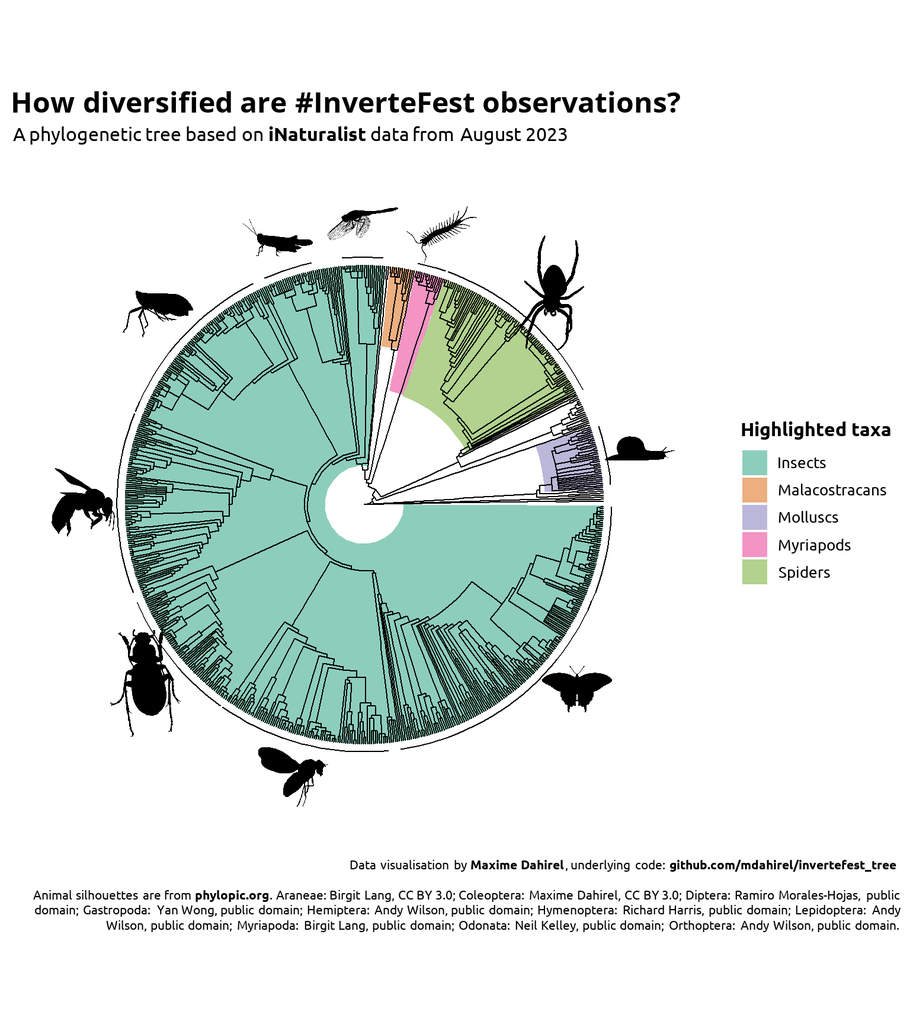

```r
font_add_google(name="Open Sans",family="Open Sans")
font_add_google(name="Ubuntu",family="Ubuntu")

# showtext_auto()

ggtree(my_tree, layout = "circular") +
  geom_highlight(data = d1, aes(node = node, fill = taxon)) +
  geom_tree() +
  geom_cladelab(
    data = d2,
    mapping = aes(node = node, label = taxon, image = image), imagesize = 0.1,
    geom = "phylopic", imagecolour = "black", offset = 1, offset.text = 10, alpha = 1
  ) +
  scale_fill_brewer(name= "**Highlighted taxa**",palette = "Dark2") +
  labs(
    title="**How diversified are #InverteFest observations?**",
    subtitle="A phylogenetic tree based on **iNaturalist** data from August 2023",
    caption = paste0(figure_author,"<br/><br/>",phylopic_credit)
  )+
  theme(text=element_text(family = "Ubuntu", size = 12),
        plot.title=element_markdown(family = "Open Sans", size = 18),
        plot.subtitle=element_markdown(family = "Ubuntu"),
        legend.title=element_markdown(family = "Ubuntu"),
        #legend.position = "bottom",
        plot.caption = element_textbox_simple(family = "Ubuntu",size=8, halign=1),
        plot.caption.position = "plot"
        )
```